# Project 2 - CA Covid-19 Vaccine Data

### What you need to get started:

1. Set your working directory to the folder with this RMD file and dataset
2. Load the libraries/packages you’ll need (eg. ggplot and zoo)
3. You will then load the dataset

Today’s project is inspired by the graphics in this article in the LA Time about COVID-19 vaccinations in California. I also included a pdf version of the article from May 10th in case the link no longer works. Link: https://www.latimes.com/projects/california-coronavirus-cases-tracking-outbreak/covid-19-vaccines-distribution/#county-comparison

Note: This dataset was downloaded on May 10, 2021 so some of the data will be different than the news by the time you do your project. If you would like to download the latest dataset, you can visit https://data.ca.gov/dataset/covid-19-vaccine-progress-dashboard-data and download the “Statewide COVID-19 Vaccines Administered By County” csv file.

If you want to learn more about the data, in this folder is also an xlsx file that gives you more of an in-depth description of the data collected. The file is called “covid-19-progress-dashboard-data-dictionary.xlsx”

```r
# Loading vaccine administered dataset
vaccine_admin <- read.csv("covid-19-progress-county-051021.csv")
head(vaccine_admin)
```

```
##            county administered_date total_doses cumulative_total_doses
## 1 All CA Counties        2020-12-15        1134                   1134
## 2 All CA Counties        2020-12-16        8119                   9253
## 3 All CA Counties        2020-12-17       25719                  34972
## 4 All CA Counties        2020-12-18       43750                  78722
## 5 All CA Counties        2020-12-19       25203                 103925
## 6 All CA Counties        2020-12-20       18945                 122870
##   pfizer_doses cumulative_pfizer_doses moderna_doses cumulative_moderna_doses
## 1         1134                    1134             0                        0
## 2         8119                    9253             0                        0
## 3        25719                   34972             0                        0
## 4        43696                   78668            54                       54
## 5        25180                  103848            23                       77
## 6        18913                  122761            32                      109
##   jj_doses cumulative_jj_doses partially_vaccinated total_partially_vaccinated
```

[output cut: 20 more lines]

### Simple Data Clean-up:

Sometimes data can be very messy. Data entry can include extra white spaces that can mess up your analysis.

So before you begin your analysis with datasets involving text, you should remove any extra white spaces.

R has a base function that will help you remove extra spaces at the beginning and end of the sentences and at the end. The are many other packages that also has this capability!

```r
# To learn more about the trimws function
?trimws
```

```
## starting httpd help server ... done
```

```r
# Creating a string of text that has an extra white space
test_text1 <- "I am writing a sentence with an extra space at the end "

# Run this code and take a look in the console, you'll notice that the output there is no longer a white space at the end
# You can change where the white space is removed, "left", "right", "both"
trimws(test_text1, which = "right")
```

```
## [1] "I am writing a sentence with an extra space at the end"
```

```r
# What do think the output of this text string will be?
# Hint: remember you will need to specify which direction you want to trim!
test_text2 <- " I am writing a sentence with an extra spaces everywhere "

# Test it out yourself with the variable test_text2 we just created!
trimws(test_text2 , which = "both")
```

```
## [1] "I am writing a sentence with an extra spaces everywhere"
```

Notes:

Now lets use trimws() on the county column in our vaccine dataset. Tip: You need to remember to assign it to a variable to see the results. Here we are re-assigning it to the county column.

```r
# Specifying "both" will ensure that extra white spaces will be removed throughout
unique(vaccine_admin$county)
```

```
##  [1] "All CA Counties"            "All CA and Non-CA Counties"
##  [3] "Outside California"         "Unknown"
##  [5] "Alameda"                    "Alpine"
##  [7] "Amador"                     "Butte"
##  [9] "Calaveras"                  "Colusa"
## [11] "Contra Costa"               "Del Norte"
## [13] "El Dorado"                  "Fresno"
## [15] "Glenn"                      "Humboldt"
## [17] "Imperial"                   "Inyo"
## [19] "Kern"                       "Kings"
## [21] "Lake"                       "Lassen"
## [23] "Los Angeles"                "Madera"
## [25] "Marin"                      "Mariposa"
## [27] "Mendocino"                  "Merced"
## [29] "Modoc"                      "Mono"
```

[output cut: 16 more lines]

```r
vaccine_admin$county <- trimws(vaccine_admin$county, which = "both")
```

In this dataset, we know that the “administered_date” column are dates but R doesn’t know that unless we specify the data type. In order for R to handle these data points as dates, you will need to tell it the date format that it is in since dates can be represented in different ways. For example, in the US dates are usually mm/dd/yyyy while Asia it is yyyy/mm/dd. To find out what %Y-%m-%d is and other formats, take a look at the link.

Link: https://www.statmethods.net/input/dates.html *Link doesn’t work*

Question: If the date is 01/Jan/2020 (e.g. dd/mmm/yyyy), what would the format be in as.Date?

```r
random_date <- "15/Jan/2020"

# Fill in the format
as.Date(random_date, format = "%d/%b/%Y")
```

```
## [1] "2020-01-15"
```

Notes:

Here, we format administered_date column with the date format

```r
vaccine_admin$administered_date <- as.Date(vaccine_admin$administered_date, format = "%Y-%m-%d")

summary(vaccine_admin)
```

```
##     county          administered_date     total_doses
##  Length:8683        Min.   :2020-12-15   Min.   :     1
##  Class :character   1st Qu.:2021-01-22   1st Qu.:   117
##  Mode  :character   Median :2021-02-27   Median :   784
##                     Mean   :2021-02-26   Mean   : 11150
##                     3rd Qu.:2021-04-03   3rd Qu.:  3766
##                     Max.   :2021-05-08   Max.   :500344
##  cumulative_total_doses  pfizer_doses    cumulative_pfizer_doses
##  Min.   :       1       Min.   :     0   Min.   :       1
##  1st Qu.:    5572       1st Qu.:    27   1st Qu.:    2236
##  Median :   30730       Median :   362   Median :   14680
##  Mean   :  587824       Mean   :  5926   Mean   :  304639
##  3rd Qu.:  175637       3rd Qu.:  2048   3rd Qu.:   88650
##  Max.   :32471842       Max.   :285110   Max.   :17257949
##  moderna_doses      cumulative_moderna_doses    jj_doses
##  Min.   :     0.0   Min.   :       0         Min.   :    0.0
##  1st Qu.:    44.5   1st Qu.:    2574         1st Qu.:    0.0
##  Median :   347.0   Median :   16110         Median :    0.0
##  Mean   :  4824.0   Mean   :  268065         Mean   :  399.4
##  3rd Qu.:  1583.0   3rd Qu.:   83266         3rd Qu.:   18.0
##  Max.   :205445.0   Max.   :14048694         Max.   :85090.0
##  cumulative_jj_doses partially_vaccinated total_partially_vaccinated
##  Min.   :      0     Min.   :     0       Min.   :      0
##  1st Qu.:      0     1st Qu.:    66       1st Qu.:   2474
##  Median :      0     Median :   448       Median :  12928
##  Mean   :  15120     Mean   :  6238       Mean   : 174897
##  3rd Qu.:   1922     3rd Qu.:  2168       3rd Qu.:  60006
##  Max.   :1165199     Max.   :275318       Max.   :6481340
##  fully_vaccinated cumulative_fully_vaccinated at_least_one_dose
##  Min.   :     0   Min.   :       0            Min.   :     0
##  1st Qu.:    11   1st Qu.:     766            1st Qu.:    70
##  Median :   214   Median :    7826            Median :   474
##  Mean   :  4888   Mean   :  215845            Mean   :  6730
##  3rd Qu.:  1443   3rd Qu.:   54082            3rd Qu.:  2274
##  Max.   :262765   Max.   :14227497            Max.   :323917
##  cumulative_at_least_one_dose california_flag
##  Min.   :       0             Length:8683
##  1st Qu.:    4352             Class :character
##  Median :   22224             Mode  :character
##  Mean   :  390743
##  3rd Qu.:  123562
##  Max.   :19607427
```

### Calculating the percentage of those vaccinated:

For this section, we will take a subset of the data. We will focus on the rows that have data for “All CA Counties”.

You have used the subset() function in some of the Udacity lessons.

```r
vaccine_CA <- subset(vaccine_admin, county == "All CA Counties")
```

Now, we will need to use R like a calculator and calculate percentages.

In the article “Tracking coronavirus vaccinations in California”, the LA Times does not give us the population count of California used to calculate percentage. So here, we’ll be using the number of 39,466,917 based on some web searches. Feel free to change this number based on other sources!

```r
CA_pop <- c(39466917)

# In these two lines, we are calculating the percentage of those who have had at least one dose (this is for those who are partially vaccinated).
# And then rounding the number to two decimal places using the round()
vaccine_CA$partial_percent <- (vaccine_CA$cumulative_at_least_one_dose/CA_pop)*100
vaccine_CA$partial_percent <- round(vaccine_CA$partial_percent, digits = 2)

# This is combining the two steps above into one to calculate the percentage of those who are fully vaccinated
vaccine_CA$fully_percent <- round(((vaccine_CA$cumulative_fully_vaccinated/CA_pop)*100), digits = 2)
```

Question: Take a look at the new percentages columns in the dataset (particularly the last one). Compare it to the percentages in the pdf (49.1% of residents have received at least one dose and 35.7% are fully vaccinated). Our percentages are close, but why do you think the calculations might differ from each other?

```r
summary(vaccine_CA)
```

```
##     county          administered_date     total_doses
##  Length:145         Min.   :2020-12-15   Min.   :  1134
##  Class :character   1st Qu.:2021-01-20   1st Qu.:111030
##  Mode  :character   Median :2021-02-25   Median :215153
##                     Mean   :2021-02-25   Mean   :219790
##                     3rd Qu.:2021-04-02   3rd Qu.:331519
##                     Max.   :2021-05-08   Max.   :492527
##  cumulative_total_doses  pfizer_doses    cumulative_pfizer_doses
##  Min.   :    1134       Min.   :  1134   Min.   :    1134
##  1st Qu.: 2097354       1st Qu.: 55147   1st Qu.: 1206534
##  Median : 8722672       Median :105949   Median : 4463730
##  Mean   :11562070       Mean   :116840   Mean   : 5991238
##  3rd Qu.:19969962       3rd Qu.:172807   3rd Qu.:10224664
##  Max.   :31869478       Max.   :281537   Max.   :16941862
##  moderna_doses    cumulative_moderna_doses    jj_doses     cumulative_jj_doses
##  Min.   :     0   Min.   :       0         Min.   :    0   Min.   :      0
##  1st Qu.: 42465   1st Qu.:  890820         1st Qu.:    0   1st Qu.:      0
##  Median : 99890   Median : 4258942         Median :    0   Median :      0
##  Mean   : 95101   Mean   : 5273374         Mean   : 7848   Mean   : 297458
##  3rd Qu.:140582   3rd Qu.: 9232595         3rd Qu.: 8571   3rd Qu.: 512703
##  Max.   :202974   Max.   :13789607         Max.   :83188   Max.   :1138009
##  partially_vaccinated total_partially_vaccinated fully_vaccinated
##  Min.   :  1134       Min.   :   1134            Min.   :     0
##  1st Qu.: 64134       1st Qu.:1365239            1st Qu.: 19416
##  Median :126702       Median :3329049            Median : 83645
##  Mean   :122878       Mean   :3429889            Mean   : 96436
##  3rd Qu.:166902       3rd Qu.:5457715            3rd Qu.:154902
##  Max.   :272111       Max.   :6333174            Max.   :258137
##  cumulative_fully_vaccinated at_least_one_dose cumulative_at_least_one_dose
##  Min.   :       0            Min.   :  1134    Min.   :    1134
##  1st Qu.:  366270            1st Qu.: 65445    1st Qu.: 1731509
##  Median : 2719116            Median :130810    Median : 6048165
##  Mean   : 4251253            Mean   :132571    Mean   : 7681142
##  3rd Qu.: 7450647            3rd Qu.:191509    3rd Qu.:13175996
##  Max.   :13983207            Max.   :318835    Max.   :19222792
##  california_flag    partial_percent fully_percent
##  Length:145         Min.   : 0.00   Min.   : 0.00
##  Class :character   1st Qu.: 4.39   1st Qu.: 0.93
##  Mode  :character   Median :15.32   Median : 6.89
##                     Mean   :19.46   Mean   :10.77
##                     3rd Qu.:33.38   3rd Qu.:18.88
##                     Max.   :48.71   Max.   :35.43
```

```r
tail(vaccine_CA)
```

```
##              county administered_date total_doses cumulative_total_doses
## 140 All CA Counties        2021-05-03      245089               30579883
## 141 All CA Counties        2021-05-04      319911               30899794
## 142 All CA Counties        2021-05-05      301909               31201703
## 143 All CA Counties        2021-05-06      306260               31507963
## 144 All CA Counties        2021-05-07      226575               31734538
## 145 All CA Counties        2021-05-08      134940               31869478
##     pfizer_doses cumulative_pfizer_doses moderna_doses cumulative_moderna_doses
## 140       150412                16115443         86224                 13363430
## 141       195409                16310852        115085                 13478515
## 142       192942                16503794         99333                 13577848
## 143       203094                16706888         93332                 13671180
## 144       144589                16851477         76911                 13748091
## 145        90385                16941862         41516                 13789607
##     jj_doses cumulative_jj_doses partially_vaccinated
```

[output cut: 27 more lines]

### Recreating the plots by the LA Times:

Now that we have calculated the percentages, we will now plot the graph like the first one in the LA Times.

We will use different functions from the graphic library ggplot2 which you have been using.

Note: All graphics in the ggplot2 library are built using a layered approach, building layers up to create the final graphic. So to build the graphic we will plot the “partially” vaccinated layer first and the “fully” vaccinated on top.

If you plot the “fully” vaccinated layer first and the “partially” vaccinated layer second, you will not be able to see the “fully” vaccinated area unless you change the opacity of the graph because the area is larger and covers the other plot/layer.

You can use differnt names of colors or hex codes for graphs. For more colors to use for graphs, you can take a look at this :link http://www.stat.columbia.edu/~tzheng/files/Rcolor.pdf

To learn more about changing the colour, fill and opacity Link: https://ggplot2.tidyverse.org/reference/aes_colour_fill_alpha.html

```r
# This will show you the column names in the dataset
names(vaccine_CA)
```

```
##  [1] "county"                       "administered_date"
##  [3] "total_doses"                  "cumulative_total_doses"
##  [5] "pfizer_doses"                 "cumulative_pfizer_doses"
##  [7] "moderna_doses"                "cumulative_moderna_doses"
##  [9] "jj_doses"                     "cumulative_jj_doses"
## [11] "partially_vaccinated"         "total_partially_vaccinated"
## [13] "fully_vaccinated"             "cumulative_fully_vaccinated"
## [15] "at_least_one_dose"            "cumulative_at_least_one_dose"
## [17] "california_flag"              "partial_percent"
## [19] "fully_percent"
```

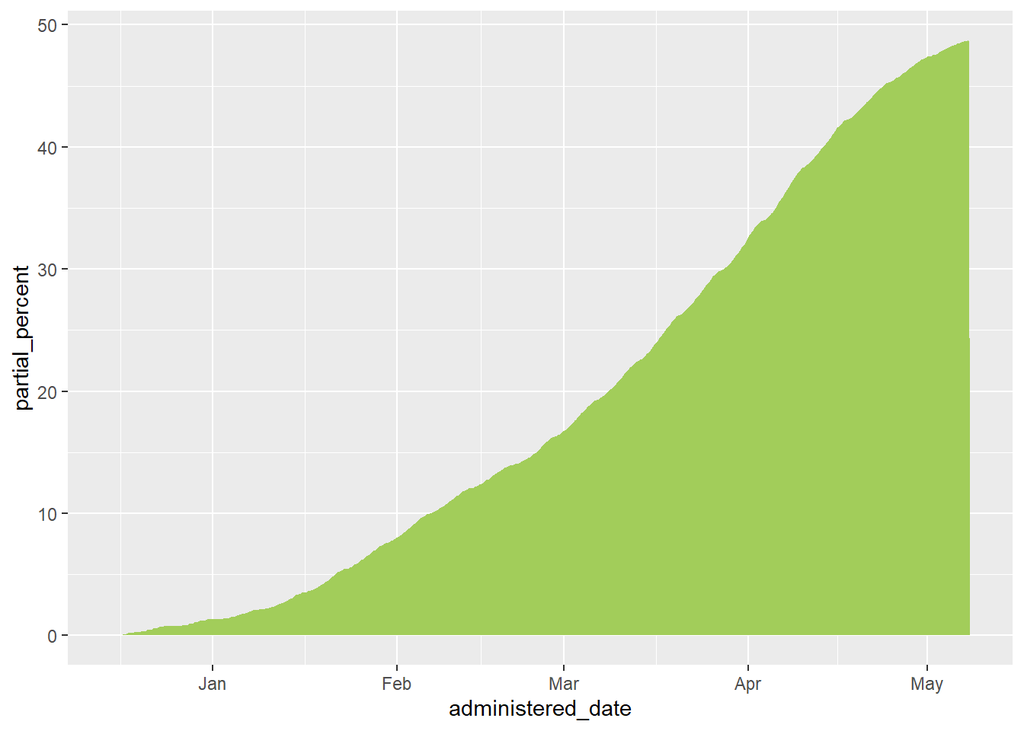

```r
# Plotting the inital graph with the first layer for the partially vaccinated percentages
ggplot(data = vaccine_CA, aes(x = administered_date, y = partial_percent)) +
  geom_area(fill = "darkolivegreen3")
```

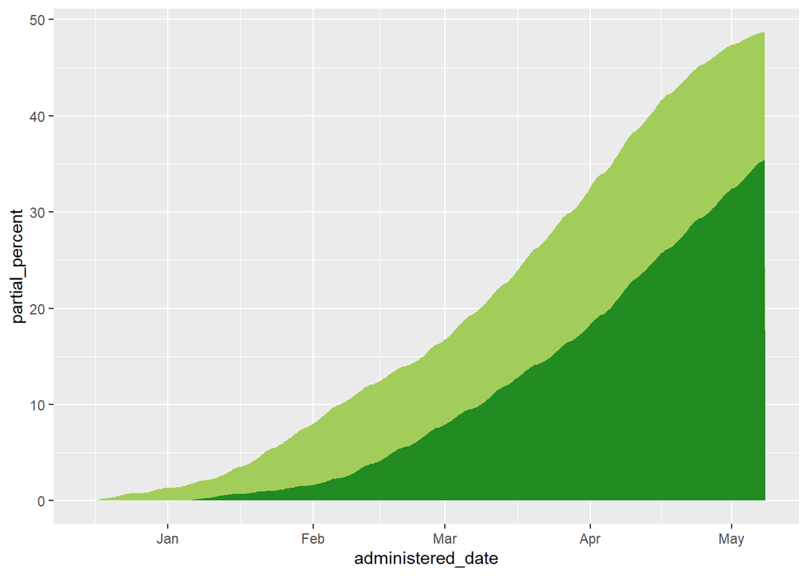

```r
# Adding the second layer with the fully vaccinated percentages
ggplot(data = vaccine_CA, aes(x = administered_date, y = partial_percent)) +
  geom_area(fill = "darkolivegreen3") +
  geom_area(aes(x = administered_date, y = fully_percent), fill="forestgreen")
```

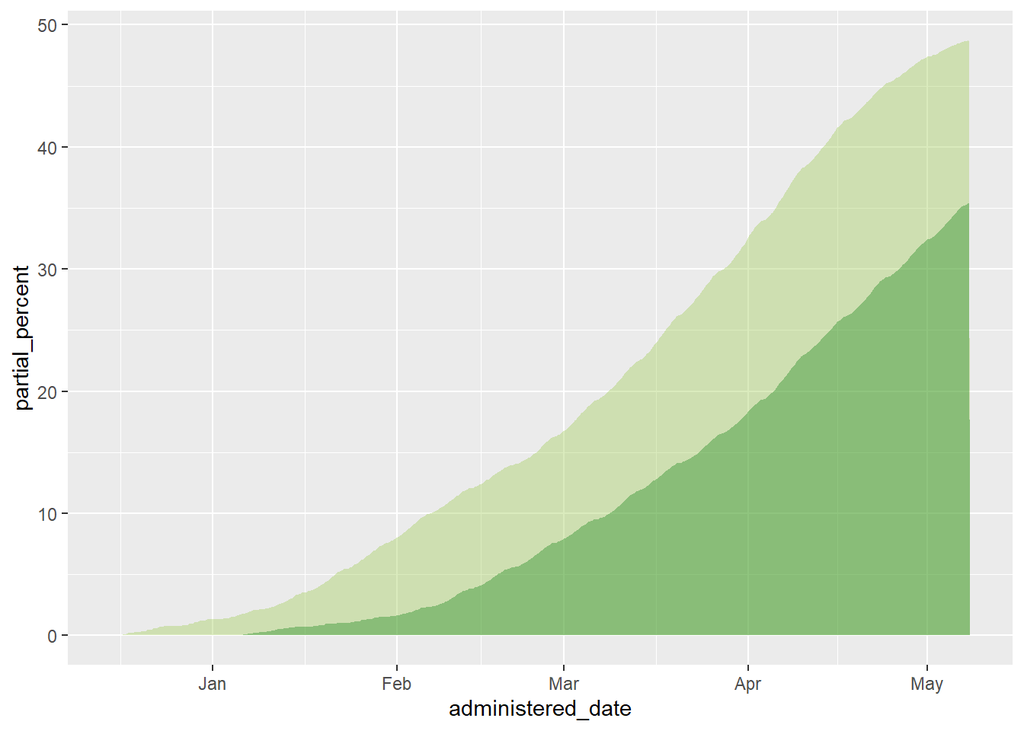

```r
# Here is an example of changing the opacity of the graph with the aesthetic parameter alpha
ggplot(data = vaccine_CA, aes(x = administered_date, y = partial_percent)) +
  geom_area(fill = "darkolivegreen3", alpha = 0.4) +
  geom_area(aes(x = administered_date, y = fully_percent), fill="forestgreen", alpha = 0.4)
```

Our plot looks pretty similar to the one in the article!

Something else we can add to this plot that isn’t shown in the article is a horizontal line. A horizontal line could be useful to show data with some goal line or limits. For example, if California’s goal is to have 80% of their residents vaccinated, the “goal line” could show where the curve should be.

In the plot below, we will first change the limits of the y-axis and then we can add a horizontal line and change the appearance of that line. Try changing the position, color and the design of the line. More information about this can be found in the link.

Link: http://www.sthda.com/english/wiki/ggplot2-line-types-how-to-change-line-types-of-a-graph-in-r-software

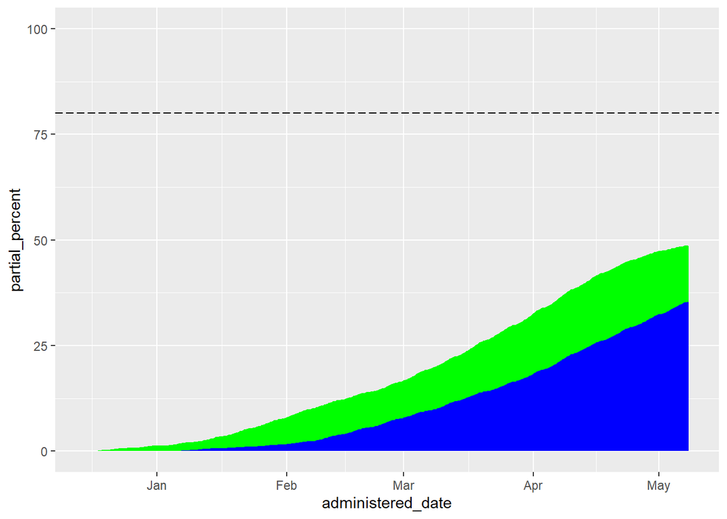

```r
# Try changing the line type with something different

ggplot(data = vaccine_CA, aes(x = administered_date, y = partial_percent)) +
  geom_area(fill="green") +
  geom_area(aes(x= administered_date, y = fully_percent), fill="blue") +
  ylim(0, 100) +
  geom_hline(yintercept = 80, linetype='longdash')
```

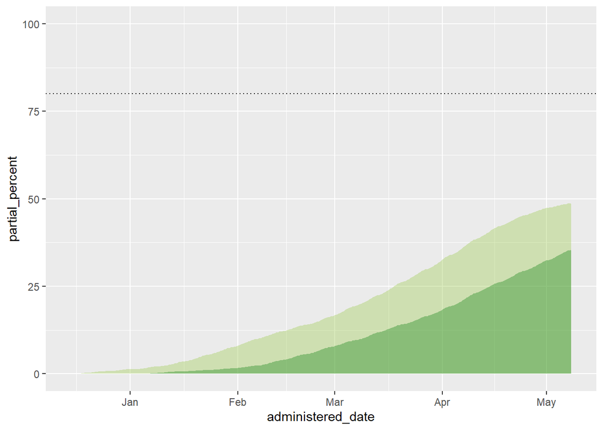

```r
ggplot(data = vaccine_CA, aes(x = administered_date, y = partial_percent)) +
  geom_area(fill = "darkolivegreen3", alpha = 0.4) +
  geom_area(aes(x = administered_date, y = fully_percent), fill="forestgreen", alpha = 0.4) +
  ylim(0, 100) + geom_hline(yintercept = 80, linetype='dotted')
```

Now, we’re going to create the second plot in the article. In that plot, they overlay a summary line.

You’ll learn more in udacity about overlaying a summary and how to do that with ggplot.

We’re going to do it a little differently using a package called “zoo”. This package was made for data involving times series.

You may need to install this package by runing the code: install.packages(“zoo”)

Note from Olivia: I was able to find this package by googling “how to calculate average for every 7 days in R”. This isn’t a package I use often so I was excited about this cool function that calculates rolling means.

You’ll see that I typed zoo::rollmean(). This is when you want to specify a function from a specific package. Sometimes function names are the same in multiple packages.

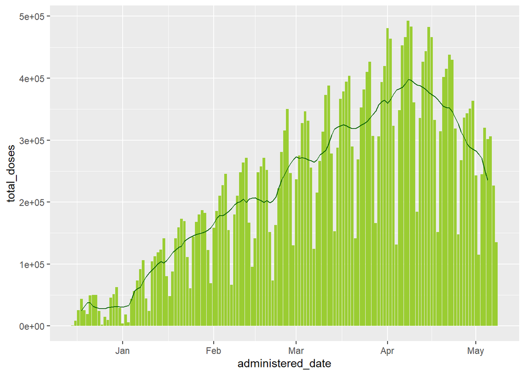

```r
# Use the function rollmean() to calculate rolling averages over 7 days
vaccine_CA$wk_avg <- zoo::rollmean(vaccine_CA$total_doses, k = 7, fill = NA)

# Round the number to the nearest whole number
vaccine_CA$wk_avg <- round(vaccine_CA$wk_avg, digits = 0)

# Because the data has NAs, a warning message will appear: "Removed 6 row(s) containing missing values (geom_path)"
# So you can na.rm = T to remove the NAs from the plot
ggplot(data = vaccine_CA, aes(x = administered_date, y = total_doses)) +
  geom_col(fill = "yellowgreen") +
  #scale_y_continuous() +
  geom_line(data = vaccine_CA, aes(x = administered_date, y = wk_avg), na.rm = T, color = "darkgreen")
```

We just completed re-creating two plots that look pretty similar to the ones in the article!

### Your turn to pick a county and recreate the plots:

Now, it’s your turn to create these plots for a county in California. There are 58 different counties to choose from! You could pick a county that you live in or a county you like to visit.

```r
# Fill in the county of your chose to subset
SF <- subset(vaccine_admin, county == "San Francisco")
summary(SF)
```

```
##     county          administered_date     total_doses    cumulative_total_doses
##  Length:145         Min.   :2020-12-15   Min.   :    7   Min.   :     7
##  Class :character   1st Qu.:2021-01-20   1st Qu.: 2742   1st Qu.: 50669
##  Mode  :character   Median :2021-02-25   Median : 6576   Median :225237
##                     Mean   :2021-02-25   Mean   : 6604   Mean   :333997
##                     3rd Qu.:2021-04-02   3rd Qu.:10307   3rd Qu.:582727
##                     Max.   :2021-05-08   Max.   :16757   Max.   :957635
##   pfizer_doses  cumulative_pfizer_doses moderna_doses  cumulative_moderna_doses
##  Min.   :   7   Min.   :     7          Min.   :   0   Min.   :     0
##  1st Qu.:1372   1st Qu.: 30534          1st Qu.:1225   1st Qu.: 20135
##  Median :3975   Median :121451          Median :2363   Median :103786
##  Mean   :4068   Mean   :199487          Mean   :2264   Mean   :124333
##  3rd Qu.:6450   3rd Qu.:356407          3rd Qu.:3039   3rd Qu.:210335
##  Max.   :9972   Max.   :589844          Max.   :6367   Max.   :328231
##     jj_doses      cumulative_jj_doses partially_vaccinated
##  Min.   :   0.0   Min.   :    0       Min.   :   7
##  1st Qu.:   0.0   1st Qu.:    0       1st Qu.:1837
##  Median :   0.0   Median :    0       Median :3478
##  Mean   : 272.8   Mean   :10177       Mean   :3673
##  3rd Qu.: 199.0   3rd Qu.:15985       3rd Qu.:5409
##  Max.   :4394.0   Max.   :39560       Max.   :9524
##  total_partially_vaccinated fully_vaccinated cumulative_fully_vaccinated
##  Min.   :     7             Min.   :   0     Min.   :     0
##  1st Qu.: 33139             1st Qu.: 574     1st Qu.:  8763
##  Median : 95579             Median :2527     Median : 64776
##  Mean   : 96144             Mean   :2920     Mean   :123814
##  3rd Qu.:156380             3rd Qu.:4625     3rd Qu.:219990
##  Max.   :188562             Max.   :9681     Max.   :423417
##  at_least_one_dose cumulative_at_least_one_dose california_flag
##  Min.   :    7     Min.   :     7               Length:145
##  1st Qu.: 1837     1st Qu.: 41902               Class :character
##  Median : 3478     Median :160355               Mode  :character
##  Mean   : 3946     Mean   :219958
##  3rd Qu.: 5970     3rd Qu.:377916
##  Max.   :10077     Max.   :572201
```

Now, you’ll need to calculate the percentages for those partially (at least one dose) and those who are fully vaccinated.

Hint: The partially vaccinated column is named “cumulative_at_least_one_dose” The fully vaccinated column is named “cumulative_fully_vaccinated”

```r
# Fill in the county's population
county_pop <- c(815000)

# Calculate the percentage the percentage of those who have had at least one dose in that county
SF$partial_percent <- (SF$cumulative_at_least_one_dose/county_pop)*100
SF$partial_percent <- round(SF$partial_percent, digits = 2)

# Calculate the percentage of those who are fully vaccinated in that county
SF$fully_percent <- round(((SF$cumulative_fully_vaccinated/county_pop)*100), digits = 2)
```

# Plot 1: Percentages for your county

Now graph the first plot of those who are partially and fully vaccinated in that county

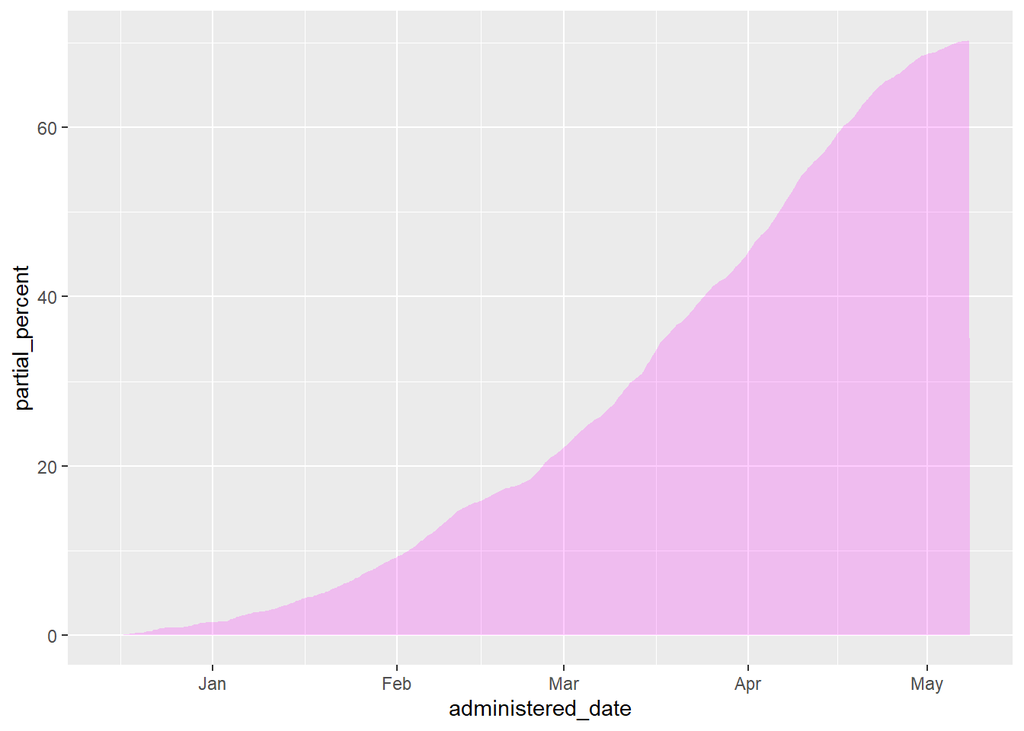

```r
ggplot(data = SF, aes(x=administered_date, y = partial_percent)) +
  geom_area(fill="magenta", alpha = 0.2)
```

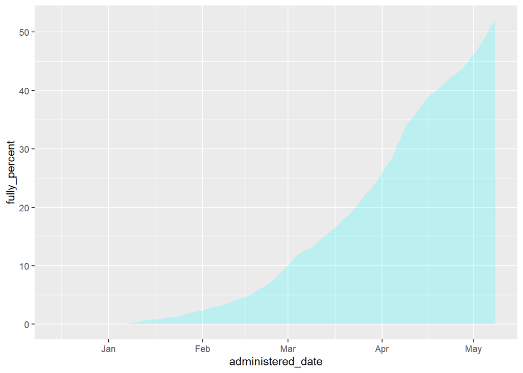

```r
ggplot(data = SF, aes(x=administered_date, y = fully_percent))+
  geom_area(fill="cyan", alpha = 0.2)
```

```r
SFplot <- ggplot(data = SF, aes(x=administered_date, y = partial_percent))+
  geom_area(fill="magenta", alpha = 0.2) +
  geom_area(aes(x = administered_date, y = fully_percent), fill="cyan", alpha = 0.25)
```

Now let’s add some labels to the plot

For the plot: 1) Add a title 2) Change the name of the x-axis 3) Change the name of the y-axis

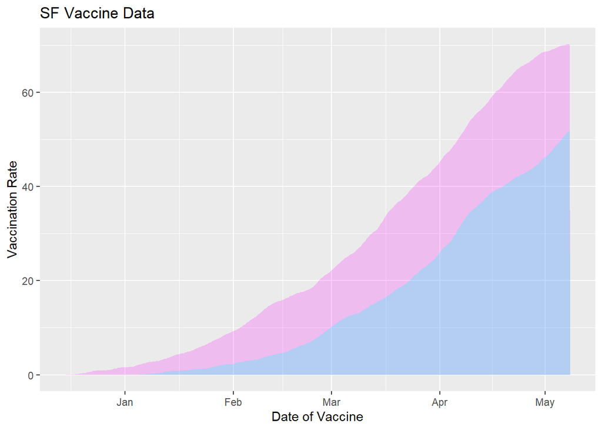

```r
SFplot + labs(x = "Date of Vaccine", y = "Vaccination Rate",
title ="SF Vaccine Data")
```

# Plot 2: Doses administered by your county

Now try the summary overlay for that county of total does administered.

Hint: remember to assign the calculations of the rolling averages to a variable like we did above!

```r
# Use the function rollmean() to calculate rolling averages over 7 days
SF$wk_avg <- zoo::rollmean(SF$total_doses , k = 7, fill = NA)

# Round the number to the nearest whole number
SF$wk_avg <- round(SF$wk_avg, digits = 0)
```

[figure not shown]

```r
ggplot(data = vaccine_CA, aes(x = administered_date, y = total_doses)) +
  geom_col(fill = "lightblue") +
  scale_y_continuous() +
  geom_line(data = vaccine_CA, aes(x = administered_date, y = wk_avg), na.rm = T,
            color = "magenta", alpha = 0.5, size = 0.8) +
  labs(x = "Date of Vaccine", y = "Total Vaccinations",
       title ="SF Vaccine Data by Day")
```

# Making a .pdf

```r
pdf("SFvaccinations.pdf")

SFplot + labs(x = "Date of Vaccine", y = "Vaccination Rate",
title ="SF Vaccine Data")

ggplot(data = vaccine_CA, aes(x = administered_date, y = total_doses)) +
  geom_col(fill = "lightblue") +
  scale_y_continuous() +
  geom_line(data = vaccine_CA, aes(x = administered_date, y = wk_avg), na.rm = T,
            color = "magenta", alpha = 0.5, size = 0.8) +
  labs(x = "Date of Vaccine", y = "Total Vaccinations",
       title ="SF Vaccine Data by Day")

dev.off()
```

Share with us one of your plots in the question-forum!